# report

```python
import os
import shutil as sh

if os.path.exists("./ATML_GestureRecognition_CNN/"):
  sh.rmtree("./ATML_GestureRecognition_CNN/")

!git clone https://github.com/milibiswas/ATML_GestureRecognition_CNN.git
```

[output not shown]

[output cut: 44 more lines]

[output not shown]

## ATML Group 3b Project report

### Course Title : Advanced Topic in Machine Learning

### Project: Gesture Recognition in American Sign Language

Prepared by

*Mili Biswas (MSc. Computer Science - University of Fribourg),* *Ivan Kravchenko (MSc. Computer Science - University of Bern)*

*Date: 18-May-2019*

## Goal

Create a model to classify american sign language images which includes alphabets as well as 10 digits. This is a classification problem to recognize different types of images belonging to Amercian Sign Language.

## Approach description

Here, we've tried to replicate the results of *et al. Bheda and Radpour* following their reseach paper on *Gesture recognition in American Sign Language using Deep CNN*. We've used same dataset and tried to build the same model. We futher improve their model to get more accuracy with better performance.

As there were less amount of dataset, we faced significant issue in terms of training the model and validating the results. This includes vanishing gradient problem and network unstablility. We have introduced batch normalization to first stable the system which has in effect solved the vanishing gradient problem. Moreover, we used ADAM optimizer in order to improve the convergence time as well as validation performance.

We futher experimented with VGG network (https://arxiv.org/abs/1409.1556) in order to implement transfer learning process where we used VGG convolution layer as initilizer of our model. This setup has also given superior performance.

In terms of dataset, we have used the massey dataset as mentioned in the original paper as well as dataset from kaggle on American Sign Language.

We used accuracy as a metric to evaluate our solution.

## Results

#### *Dataset : Massey*

[output not shown]

#### *Dataset : Kaggle(with background noise)*

Results show model is overfitting.

| Model | Train accuracy [\%] | Valid accuracy [\%] | Test accuracy [\%] |
| --- | --- | --- | --- |
| Raw model (without Batch norm) | **86.30** | **75.59** | **73.80** |
| Improved model (with Batch Norm & new optimizer) | **98.31** | **78.57** | **78.57** |
| Pretrained (Finetuning) | **98.61** | **77.67** | **75.29** |

## Learning curves

[figure not shown]

#### *Figure1 - Train/validation loss (left) and Train/validation accuracy (right) for improved CNN model (without pretrained) with massey dataset*

[figure not shown]

#### *Figure2 - Train/validation loss (left) and Train/validation accuracy (right) for Pretrained model (VGG Finetuning) with massey dataset*

[figure not shown]

#### *Figure3 - Batch norm values without pretrained (left) and with pretrained (right) based on massey data*

## Network Architecture

In this experiment, we have used an improved version of original CNN model that is available in the research paper where we introduced the additional batch normalization maong layers in convolution neural network part. Moreover, we have also used part of pretrained model's (VGG16) CNN layer along with original model's cliassification to make the whole system as finetuning architecture.

[figure not shown]

[figure not shown]

[figure not shown]

[figure not shown]

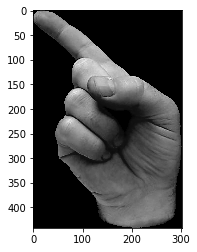

```python
# example of train data
from matplotlib import pyplot as plt
import torch
from PIL import Image
# Load sample image
import numpy as np
plt.figure()
image = Image.open('./ATML_GestureRecognition_CNN/pic/hand4_z_bot_seg_5_cropped.png').convert('L')
image = np.array(image)
# Show image
%matplotlib inline
import matplotlib.pyplot as plt
plt.imshow(image, cmap='gray')
```

### The above image is from Massey Dataset

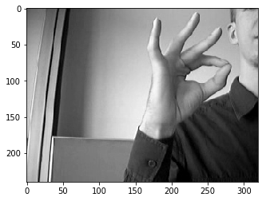

```python
image = Image.open('./ATML_GestureRecognition_CNN/pic/F5.jpg').convert('L')
image = np.array(image)
# Show image
import matplotlib.pyplot as plt
plt.figure()
plt.imshow(image, cmap='gray')
```

### The above image is from Kaggle Dataset

```python
%cd ./ATML_GestureRecognition_CNN/bin
from torch.autograd import Variable
import numpy as np
from torchvision import models
import torch
import torch.nn as nn
import matplotlib
matplotlib.use('Agg')
from matplotlib import pyplot as plt
from torch.utils.data import DataLoader
import data_loader_massey as dlm
import data_loader_kaggle as dlk

device = torch.device('cuda') if torch.cuda.is_available() else torch.device('cpu')
```

```
[WinError 3] The system cannot find the path specified: './ATML_GestureRecognition_CNN/bin'
C:\Users\somde\Desktop\ATML\project\ATML_GestureRecognition_CNN\bin
```

## Below code implements the CNN model

```python
#####################################################################################
#  Activate the dataset you want to use & Type of model (e.g. Pretrained or not)
#

DATASET_MESSEY=True
VGG_PRETRAINED=False


'''
    DO NOT Change the below parameters. Otherwise, dimension mismatch could occur!
'''

if not DATASET_MESSEY:
  LINEAR_LAYER_FINAL_DIM=26
else:
  LINEAR_LAYER_FINAL_DIM=36

if not VGG_PRETRAINED:
  LINEAR_LAYER_INITIAL_DIM=64*12*12
else:
  LINEAR_LAYER_INITIAL_DIM=256*32*32


batchNorm=[]

def getBatchNorm(e,model):
  total_norm=0
  for p in model.parameters():
    param_norm = p.grad.data.norm(2)
  total_norm += param_norm.item() ** 2
  total_norm = total_norm ** (1. / 2)
  batchNorm.append(total_norm)
  print("Epoch{} the batch norm is : {}".format(e,total_norm))

# preparing the model


class __dataset(object):
    def __init__(self,feat,labels):
        self.conv_feat=feat
        self.labels=labels
    def __len__(self,):
        return len(self.conv_feat)
    def __getitem__(self,idx):
        return self.conv_feat[idx],self.labels[idx]

def preconvfeat(dataset,model):
    conv_features=[]
    labels_lst=[]
    avgPool=nn.AdaptiveAvgPool2d((7,7))
    for data in dataset:
        images,labels = data
        images=images.to(device)
        labels=labels.to(device)
        images=Variable(images)
        labels=Variable(labels)
        output=model(images)
        output=avgPool(output)
        conv_features.extend(output)
        labels_lst.extend(labels)
    conv_features=torch.stack(conv_features)
    labels=torch.stack(labels_lst)
    return (conv_features,labels_lst)


class ConvModel(nn.Module):
    def __init__(self,):
        super(ConvModel,self).__init__()
        self.conv_layer=nn.Sequential(
                nn.Conv2d(3,16,kernel_size=3,padding=0),
                nn.BatchNorm2d(num_features=16),
                nn.ReLU(),
                nn.Conv2d(16,16,kernel_size=3,padding=0),
                nn.BatchNorm2d(num_features=16),
                nn.ReLU(),
                nn.MaxPool2d(kernel_size=2),
                nn.Dropout(0.25),
                nn.Conv2d(16,32,kernel_size=3,padding=0),
                nn.BatchNorm2d(num_features=32),
                nn.ReLU(),
                nn.Conv2d(32,32,kernel_size=3,padding=0),
                nn.BatchNorm2d(num_features=32),
                nn.ReLU(),
                nn.MaxPool2d(kernel_size=2),
                nn.Dropout(0.25),
                nn.Conv2d(32,64,kernel_size=3,padding=0),
                nn.BatchNorm2d(num_features=64),
                nn.ReLU(),
                nn.Conv2d(64,64,kernel_size=3,padding=0),
                nn.BatchNorm2d(num_features=64),
                nn.ReLU(),
                nn.MaxPool2d(kernel_size=2),
                nn.Dropout(0.25)
                )
        self.linear_layer=nn.Sequential(
                nn.Linear(LINEAR_LAYER_INITIAL_DIM,128),
                nn.Dropout(0.5),
                nn.Linear(128,128),
                nn.Dropout(0.5),
                nn.Linear(128,LINEAR_LAYER_FINAL_DIM)
                )
    def forward(self,input):
        conv_out = self.conv_layer(input)
        conv_out_flat = conv_out.view(conv_out.size(0),-1)
        out=self.linear_layer(conv_out_flat)
        return out

# train/ validate the model

def train(model,train_dataloader,loss_fn,optimizer):
    train_loss = 0
    n_correct = 0
    for (images,labels) in train_dataloader:
        images=images.to(device)
        labels=labels.to(device)
        out = model(images)
        loss = loss_fn(out,labels)
        optimizer.zero_grad()
        loss.backward()
        optimizer.step()
        train_loss += loss.item()
        n_correct += torch.sum(out.argmax(1)==labels).item()
    accuracy = (100*n_correct)/len(train_dataloader.dataset)
    average_loss = train_loss/len(train_dataloader)
    return average_loss,accuracy

def valid(model,valid_dataloader,loss_fn):
    valid_loss = 0
    n_correct = 0
    with torch.no_grad():
        for (images,labels) in valid_dataloader:
            images=images.to(device)
            labels=labels.to(device)
            out = model(images)
            loss = loss_fn(out,labels)
            valid_loss +=loss.item()
            n_correct += torch.sum(out.argmax(1)==labels).item()
        accuracy = 100*n_correct / len(valid_dataloader.dataset)
        average_loss = valid_loss/len(valid_dataloader)
        return average_loss,accuracy

def test(model,test_dataloader):
    n_correct = 0
    with torch.no_grad():
        for (images,labels) in test_dataloader:
            images=images.to(device)
            labels=labels.to(device)
            out = model(images)
            n_correct += torch.sum(out.argmax(1)==labels).item()
        accuracy = 100*n_correct / len(test_dataloader.dataset)
        return accuracy

def fit(model,train_dataloader,valid_dataloader,loss_fn,optimizer,n_epoch,dataObj):
    train_losses = []
    train_accuracies = []
    valid_losses = []
    valid_accuracies = []
    for kfold in range(1):
        for epoch in range(n_epoch):
            train_loss,train_accuracy = train(model,train_dataloader,loss_fn,optimizer)
            train_losses.append(train_loss)
            train_accuracies.append(train_accuracy)
            valid_loss,valid_accuracy = valid(model,valid_dataloader,loss_fn)
            valid_losses.append(valid_loss)
            valid_accuracies.append(valid_accuracy)
            print("Epoch:{}, train loss:{}, train accuracy:{}, validation loss:{}, validation accuracy:{}, loss diff:{}".format(epoch,train_loss,train_accuracy,valid_loss,valid_accuracy,abs(train_loss-valid_loss)))
            #print("Epoch:{} the validation loss is {} and the validation accuracy is {}".format(epoch,valid_loss,valid_accuracy))
            getBatchNorm(epoch,model)
    return train_losses , train_accuracies,valid_losses,valid_accuracies



def plot(n_epochs, train_losses, val_losses, train_accuracies, val_accuracies):
    plt.figure()
    plt.plot(np.arange(n_epochs), train_losses)
    plt.plot(np.arange(n_epochs), val_losses)
    plt.legend(['train_loss', 'val_loss'])
    plt.xlabel('epoch')
    plt.ylabel('loss value')
    plt.title('Train/val loss');

    plt.figure()
    plt.plot(np.arange(n_epochs), train_accuracies)
    plt.plot(np.arange(n_epochs), val_accuracies)
    plt.legend(['train_acc', 'val_acc'])
    plt.xlabel('epoch')
    plt.ylabel('accuracy')
    plt.title('Train/val accuracy')
    plt.savefig("train_valid.png")

def plot_batch_norm(n_epochs, batch_norm):
    plt.figure()
    plt.scatter(range(n_epochs), batch_norm)
    plt.legend(['Batch Norm Value'])
    plt.xlabel('epoch')
    plt.ylabel('batch norm value')
    plt.title('Batch norm changes')
    plt.savefig("batch_norm.png")
```

## Below code runs our improved CNN model with Massey dataset

```
Test data preparation phase
Validation data preparation phase
Train data preparation phase
Epoch:0, train loss:4.118129759418721, train accuracy:0.8287292817679558, validation loss:3.770549269283519, validation accuracy:3.7267080745341614, loss diff:0.3475804901352024
Epoch0 the batch norm is : 1.014718770980835
Epoch:1, train loss:3.885665475105753, train accuracy:0.6906077348066298, validation loss:3.430533353020163, validation accuracy:8.074534161490684, loss diff:0.45513212208558995
Epoch1 the batch norm is : 0.9861220717430115
Epoch:2, train loss:3.5928477511114005, train accuracy:2.7624309392265194, validation loss:3.2644879116731533, validation accuracy:15.320910973084887, loss diff:0.3283598394382472
Epoch2 the batch norm is : 0.9537323117256165
Epoch:3, train loss:3.3811548534704716, train accuracy:6.975138121546961, validation loss:3.0929316212149227, validation accuracy:21.532091097308488, loss diff:0.2882232322555489
Epoch3 the batch norm is : 0.9583960771560669
Epoch:4, train loss:3.208525540877362, train accuracy:12.638121546961326, validation loss:2.9351064738105324, validation accuracy:23.80952380952381, loss diff:0.2734190670668295
Epoch4 the batch norm is : 0.9327360987663269
Epoch:5, train loss:3.006992262236926, train accuracy:17.265193370165747, validation loss:2.6932296051698574, validation accuracy:31.884057971014492, loss diff:0.3137626570670684
Epoch5 the batch norm is : 0.9296479821205139
Epoch:6, train loss:2.829372612797484, train accuracy:21.201657458563535, validation loss:2.602514295017018, validation accuracy:34.57556935817805, loss diff:0.22685831778046595
Epoch6 the batch norm is : 0.7212594747543335
Epoch:7, train loss:2.6807691929291706, train accuracy:25.89779005524862, validation loss:2.4308067279703476, validation accuracy:36.231884057971016, loss diff:0.24996246495882302
Epoch7 the batch norm is : 0.8702212572097778
Epoch:8, train loss:2.4751793219118703, train accuracy:29.903314917127073, validation loss:2.2584641330382405, validation accuracy:41.200828157349896, loss diff:0.21671518887362984
Epoch8 the batch norm is : 0.9227240085601807
Epoch:9, train loss:2.3169978224501317, train accuracy:32.73480662983425, validation loss:2.1526538133621216, validation accuracy:45.75569358178054, loss diff:0.16434400908801017
Epoch9 the batch norm is : 0.8320810198783875
Epoch:10, train loss:2.147326043673924, train accuracy:38.466850828729285, validation loss:1.9869320883470423, validation accuracy:44.927536231884055, loss diff:0.16039395532688183
Epoch10 the batch norm is : 0.7790979743003845
Epoch:11, train loss:2.0192041907991682, train accuracy:42.67955801104972, validation loss:1.9477906998466044, validation accuracy:49.68944099378882, loss diff:0.07141349095256389
Epoch11 the batch norm is : 0.6782837510108948
Epoch:12, train loss:1.8872042675407565, train accuracy:44.751381215469614, validation loss:1.8189718512927784, validation accuracy:50.31055900621118, loss diff:0.06823241624797816
Epoch12 the batch norm is : 0.5144729614257812
Epoch:13, train loss:1.7758317954686222, train accuracy:48.82596685082873, validation loss:1.7632824112387264, validation accuracy:52.38095238095238, loss diff:0.012549384229895821
Epoch13 the batch norm is : 0.5273488163948059
Epoch:14, train loss:1.6940421109296837, train accuracy:49.171270718232044, validation loss:1.6170679751564474, validation accuracy:55.072463768115945, loss diff:0.07697413577323631
Epoch14 the batch norm is : 0.572294294834137
Epoch:15, train loss:1.6111730616919848, train accuracy:51.8646408839779, validation loss:1.5210908125428593, validation accuracy:57.7639751552795, loss diff:0.09008224914912555
Epoch15 the batch norm is : 0.6989193558692932
Epoch:16, train loss:1.5547924990556679, train accuracy:54.488950276243095, validation loss:1.539624035358429, validation accuracy:55.072463768115945, loss diff:0.015168463697238899
Epoch16 the batch norm is : 0.6632509827613831
Epoch:17, train loss:1.4394366960136258, train accuracy:57.18232044198895, validation loss:1.4879690338583553, validation accuracy:58.178053830227746, loss diff:0.048532337844729545
Epoch17 the batch norm is : 0.45938336849212646
Epoch:18, train loss:1.3351338019176406, train accuracy:59.806629834254146, validation loss:1.4006725164020764, validation accuracy:59.42028985507246, loss diff:0.06553871448443571
```

[output cut: 351 more lines]

```
Epoch:194, train loss:0.03285017004711743, train accuracy:98.75690607734806, validation loss:0.29017761733163805, validation accuracy:93.16770186335404, loss diff:0.2573274472845206
Epoch194 the batch norm is : 0.00032095270580612123
Epoch:195, train loss:0.024485831734859766, train accuracy:99.30939226519337, validation loss:0.44996432193061886, validation accuracy:91.92546583850931, loss diff:0.4254784901957591
Epoch195 the batch norm is : 0.0028005230706185102
Epoch:196, train loss:0.023615855502073978, train accuracy:99.24033149171271, validation loss:0.45933086171006676, validation accuracy:92.7536231884058, loss diff:0.4357150062079928
Epoch196 the batch norm is : 0.00012897758278995752
Epoch:197, train loss:0.02644528137824061, train accuracy:99.17127071823204, validation loss:0.4044025847962236, validation accuracy:90.47619047619048, loss diff:0.377957303417983
Epoch197 the batch norm is : 0.12492102384567261
Epoch:198, train loss:0.03206835427364258, train accuracy:98.75690607734806, validation loss:0.47446022977066393, validation accuracy:90.89026915113871, loss diff:0.44239187549702136
Epoch198 the batch norm is : 1.4997544894868042e-05
Epoch:199, train loss:0.0549151946728745, train accuracy:98.1353591160221, validation loss:0.5383134722052252, validation accuracy:91.51138716356108, loss diff:0.4833982775323507
Epoch199 the batch norm is : 0.044144902378320694
======================== Test Accurracy Score ========================
Accuracy Score :  92.7536231884058
========================        End           ========================
```

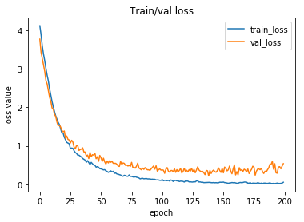

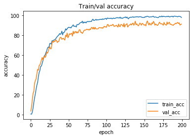

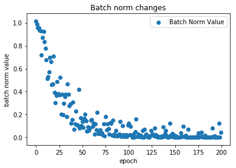

```python
%matplotlib inline
model=None
if not DATASET_MESSEY:

  if not VGG_PRETRAINED:
        d=dlk.data_loader_kaggle()
        train_dataloader=d.train_dataloader
        valid_dataloader=d.valid_dataloader

        #........................................
        #  Model, loss function & optimizer
        #----------------------------------------

        model = ConvModel()
        model = model.to(device)
        loss_fn = nn.CrossEntropyLoss()
        #optimizer = torch.optim.SGD(model.parameters(), lr=0.0001, momentum=0.5)
        optimizer = torch.optim.Adam(model.parameters(),lr=.0001)

        #----------------------------------------
        #  Fit function calls
        #----------------------------------------

        t_losses , t_accuracies,v_losses,v_accuracies = fit(model,train_dataloader,valid_dataloader,loss_fn,optimizer,200,d)

        #----------------------------------------
        #  Testing & Accuracy Calculation
        #----------------------------------------

        test_dataloader = d.test_dataloader
        test_accuracy=test(model,test_dataloader)
        print("======================== Test Accurracy Score ========================")
        print("Accuracy Score : ",test_accuracy)
        print("========================        End           ========================")

        plot(200, t_losses, v_losses, t_accuracies, v_accuracies)
        plot_batch_norm(200,batchNorm)

  if VGG_PRETRAINED:

    d=dlk.data_loader_kaggle()
    train_dataloader=d.train_dataloader
    valid_dataloader=d.valid_dataloader

    #----------------------------------------
    #  Model, loss function & optimizer
    #----------------------------------------

    vgg=models.vgg16(pretrained=True)

    vggConvNet=nn.Sequential(*list(vgg.features.children())[0:14])
    for params in vgg.parameters():
        params.requires_grad=True
    model = ConvModel()
    model.conv_layer=vggConvNet
    model = model.to(device)
    loss_fn = nn.CrossEntropyLoss()
    #optimizer = torch.optim.SGD(model.parameters(), lr=0.0001, momentum=0.5)
    optimizer = torch.optim.Adam(model.parameters(),lr=.0001)

    #----------------------------------------
    #  Fit function calls
    #----------------------------------------

    t_losses , t_accuracies,v_losses,v_accuracies = fit(model,train_dataloader,valid_dataloader,loss_fn,optimizer,100,d)

    #----------------------------------------
    #  Testing & Accuracy Calculation
    #----------------------------------------

    test_dataloader = d.test_dataloader
    test_accuracy=test(model,test_dataloader)
    print("======================== Test Accurracy Score ========================")
    print("Accuracy Score : ",test_accuracy)
    print("========================        End           ========================")

    plot(100, t_losses, v_losses, t_accuracies, v_accuracies)
    plot_batch_norm(100,batchNorm)

if DATASET_MESSEY:

  if not VGG_PRETRAINED:
        d=dlm.data_loader_messey()
        train_dataloader=d.train_dataloader
        valid_dataloader=d.valid_dataloader

        #----------------------------------------
        #  Model, loss function & optimizer
        #----------------------------------------
        model = ConvModel()
        model = model.to(device)
        loss_fn = nn.CrossEntropyLoss()
        #optimizer = torch.optim.SGD(model.parameters(), lr=0.0001, momentum=0.5)
        optimizer = torch.optim.Adam(model.parameters(),lr=.0001)
        #----------------------------------------
        #  Fit function calls
        #----------------------------------------
        t_losses , t_accuracies,v_losses,v_accuracies = fit(model,train_dataloader,valid_dataloader,loss_fn,optimizer,200,d)

        #----------------------------------------
        #  Testing & Accuracy Calculation
        #----------------------------------------

        test_dataloader = d.test_dataloader
        test_accuracy=test(model,test_dataloader)
        print("======================== Test Accurracy Score ========================")
        print("Accuracy Score : ",test_accuracy)
        print("========================        End           ========================")

        plot(200, t_losses, v_losses, t_accuracies, v_accuracies)
        plot_batch_norm(200,batchNorm)

  if VGG_PRETRAINED:

    d=dlm.data_loader_messey()
    train_dataloader=d.train_dataloader
    valid_dataloader=d.valid_dataloader

    #----------------------------------------
    #  Model, loss function & optimizer
    #----------------------------------------

    vgg=models.vgg16(pretrained=True)

    vggConvNet=nn.Sequential(*list(vgg.features.children())[0:14])
    for params in vgg.parameters():
        params.requires_grad=True
    model = ConvModel()
    model.conv_layer=vggConvNet
    model = model.to(device)
    loss_fn = nn.CrossEntropyLoss()
    #optimizer = torch.optim.SGD(model.parameters(), lr=0.0001, momentum=0.5)
    optimizer = torch.optim.Adam(model.parameters(),lr=.0001)

    #----------------------------------------
    #  Fit function calls
    #----------------------------------------

    t_losses , t_accuracies,v_losses,v_accuracies = fit(model,train_dataloader,valid_dataloader,loss_fn,optimizer,100,d)

    #----------------------------------------
    #  Testing & Accuracy Calculation
    #----------------------------------------

    test_dataloader = d.test_dataloader
    test_accuracy=test(model,test_dataloader)
    print("======================== Test Accurracy Score ========================")
    print("Accuracy Score : ",test_accuracy)
    print("========================        End           ========================")

    plot(100, t_losses, v_losses, t_accuracies, v_accuracies)
    plot_batch_norm(100,batchNorm)
```

## Visualization of Intermediate Layer of CNN

```
Test data preparation phase
Validation data preparation phase
Train data preparation phase
```

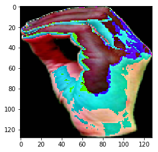

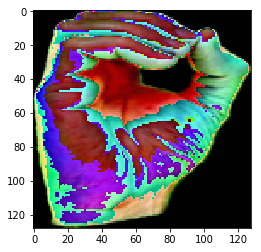

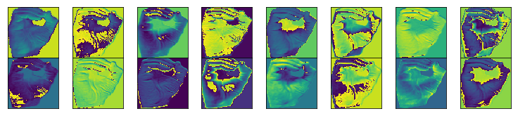

```python
from torchvision import transforms
d=None
if DATASET_MESSEY:
  d=dlm.data_loader_messey()
else:
  d=dlk.data_loader_kaggle()
plt.figure()
plt.imshow(transforms.ToPILImage()(d.train_dataset[1][0].cpu()))
train_dataloader=d.train_dataloader
class LayerActivations():
  features=None
  def __init__(self, model, layer_num):
    self.hook=model[layer_num].register_forward_hook(self.hook_fn)

  def hook_fn(self,module,input,output):
    self.features=output.cpu()
  def remove(self):
    self.hook.remove()


conv_out= LayerActivations(model.conv_layer,0)

for (images,labels) in train_dataloader:
  images=images.to(device)
  pic=images[0:1,:,:,:]
  model(pic)
  plt.figure()
  plt.imshow(transforms.ToPILImage()(pic[0].cpu()))
  break

conv_out.remove()
act=conv_out.features


fig=plt.figure(figsize=(10,10))
fig.subplots_adjust(left=0,right=1,bottom=0,top=0.8,hspace=0,wspace=0.2)
for i in range(16):
  ax=fig.add_subplot(8,8,i+1,xticks=[],yticks=[])
  ax.imshow(transforms.ToPILImage()(act[0][i]))
```

## Visualization of weights in intermediate CNN layer

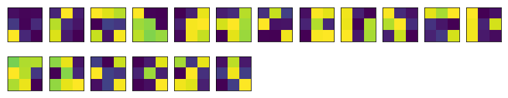

```python
################################## Weight Visualization ######################################

model.state_dict().keys()
cnn_weights=model.state_dict()['conv_layer.0.weight'].cpu()


fig=plt.figure(figsize=(10,10))
fig.subplots_adjust(left=0,right=1,bottom=0,top=0.8,hspace=0,wspace=0.2)
for i in range(16):
  for j in range(3):
    ax=fig.add_subplot(8,12,i+j+1,xticks=[],yticks=[])
    ax.imshow(transforms.ToPILImage()(cnn_weights[i][j]))
```

## Conclusion

We have observed that, when with massey data, our model is very stable and performing very good, with kaggle data, the model tends to be overfitting. We assume that, this is due to the background and other factors associated noise with each image in kaggle dataset.

It has to be noted that, since the dataset size is very small (approx. 2000 images) in American Sign Language domain, we have done data augmentation with random horizontal flipping and random rotation.